# DS4P: Data Types and Levels of Measurement

DS4P: Data Types and Levels of Measurement Lecture 4

## Learning Objectives

1. Understand the five basic data types in R: numeric, integer, factor, character, and logical
2. Learn how to check and convert between different data types using R functions
3. Master the four levels of measurement: nominal, ordinal, interval, and ratio
4. Understand the difference between discrete and continuous variables
5. Apply these concepts to make informed decisions about how to store and analyze your data

## What Is This For?

When you open a new dataset, one of your first tasks is understanding what kinds of variables you’re working with. Not all data is created equal - some variables represent categories (like political party affiliation), others represent ordered rankings (like movie ratings), and still others represent precise measurements (like vote percentages).

Understanding data types and measurement levels is crucial because:

- It determines which statistical analyses you can perform
- It affects how R stores and processes your data
- It helps you avoid common errors like trying to calculate the average political party
- It ensures you’re interpreting your results correctly

Think of this as learning the “grammar” of data - just as you need to know whether a word is a noun or verb to use it properly in a sentence, you need to know whether a variable is nominal or ratio to analyze it properly.

## Basic Data Types in R

R recognizes several fundamental data types. Each column in your dataset can be a different type, and R needs to know which type each variable is to handle it correctly.

### The Five Main Data Types

**1. Numeric**: Real numbers with decimal places

- Examples: 3.14, 98.6, 0.5
- Political science example: Vote share (0.523 means 52.3% of votes)

**2. Integer**: Whole numbers without decimal places

- Examples: 1, 42, -10
- Political science example: Number of Senate seats (100)

**3. Character**: Text strings

- Examples: “Democrat”, “Republican”, “Independent”
- Political science example: Country names, survey responses

**4. Factor**: Categorical data with defined levels

- Like character, but R knows there are only specific possible values
- Political science example: Region (Northeast, South, Midwest, West)

**5. Logical**: TRUE/FALSE values

- Only two possible values: TRUE or FALSE
- Political science example: Whether a bill passed (TRUE) or failed (FALSE)

### Why Data Types Matter

Functions in R only work with appropriate data types. You can’t calculate the mean of country names, and R prevents you from trying:

```r
# This won't work - and that's good!
countries <- c("USA", "Canada", "Mexico")
mean(countries)
```

```
## [1] NA
```

## Working with Data Types

Let’s load the movies dataset to explore data types in practice. You can find this dataset on canvas in the datasets folder.

```r
# Load the movies dataset
MovieData <- read.csv("movies.csv")

# Look at the structure
str(MovieData)
```

```
## 'data.frame':    651 obs. of  32 variables:
##  $ title           : chr  "Filly Brown" "The Dish" "Waiting for Guffman" "The Age of Innocence" ...
##  $ title_type      : chr  "Feature Film" "Feature Film" "Feature Film" "Feature Film" ...
##  $ genre           : chr  "Drama" "Drama" "Comedy" "Drama" ...
##  $ runtime         : int  80 101 84 139 90 78 142 93 88 119 ...
##  $ mpaa_rating     : chr  "R" "PG-13" "R" "PG" ...
##  $ studio          : chr  "Indomina Media Inc." "Warner Bros. Pictures" "Sony Pictures Classics" "Columbia Pictures" ...
##  $ thtr_rel_year   : int  2013 2001 1996 1993 2004 2009 1986 1996 2012 2012 ...
##  $ thtr_rel_month  : int  4 3 8 10 9 1 1 11 9 3 ...
##  $ thtr_rel_day    : int  19 14 21 1 10 15 1 8 7 2 ...
##  $ dvd_rel_year    : int  2013 2001 2001 2001 2005 2010 2003 2004 2013 2012 ...
##  $ dvd_rel_month   : int  7 8 8 11 4 4 2 3 1 8 ...
##  $ dvd_rel_day     : int  30 28 21 6 19 20 18 2 21 14 ...
##  $ imdb_rating     : num  5.5 7.3 7.6 7.2 5.1 7.8 7.2 5.5 7.5 6.6 ...
##  $ imdb_num_votes  : int  899 12285 22381 35096 2386 333 5016 2272 880 12496 ...
```

[output cut: 18 more lines]

### Checking Data Types

Use the `class()` function to check any variable’s type:

```r
class(MovieData$title)      # Character - movie titles are text
```

```
## [1] "character"
```

```r
class(MovieData$runtime)    # Integer - runtime in whole minutes
```

```
## [1] "integer"
```

```r
class(MovieData$imdb_rating)  # Numeric - ratings with decimals
```

```
## [1] "numeric"
```

### Converting Between Types

Use functions that start with `as.` to convert between types:

```r
# Convert runtime from integer to numeric
MovieData$runtime <- as.numeric(MovieData$runtime)
class(MovieData$runtime)
```

```
## [1] "numeric"
```

```r
# But be careful - nonsensical conversions create NAs
as.numeric("Hello")  # Can't turn text into numbers!
```

```
## [1] NA
```

### Understanding Factors

Factors are R’s way of handling categorical data efficiently. They’re stored as numbers internally but displayed as text:

```r
# Convert genre to a factor
MovieData$genre <- as.factor(MovieData$genre)

# See the levels
levels(MovieData$genre)
```

```
##  [1] "Action & Adventure"        "Animation"
##  [3] "Art House & International" "Comedy"
##  [5] "Documentary"               "Drama"
##  [7] "Horror"                    "Musical & Performing Arts"
##  [9] "Mystery & Suspense"        "Other"
## [11] "Science Fiction & Fantasy"
```

```r
# How many movies in each genre?
table(MovieData$genre)
```

```
##
##        Action & Adventure                 Animation Art House & International
##                        65                         9                        14
##                    Comedy               Documentary                     Drama
##                        87                        52                       305
##                    Horror Musical & Performing Arts        Mystery & Suspense
##                        23                        12                        59
##                     Other Science Fiction & Fantasy
##                        16                         9
```

Factors are useful because:

1. They prevent typos (R knows the valid categories)
2. They save memory (stored as numbers internally)
3. They prevent inappropriate calculations

```r
# R won't let you do math on factors - good!
mean(MovieData$genre)
```

```
## [1] NA
```

## Levels of Measurement

Beyond R’s data types, we need to understand the **conceptual** level at which variables are measured. This determines what analyses make sense.

### 1. Nominal (Categorical) Scale

**Definition**: Categories with no inherent order

- Can distinguish between groups
- No meaningful ranking
- Numbers are just labels

**Examples**:

- Political party affiliation (Democrat, Republican, Independent)
- Country of origin
- Religion
- Movie genre

**What you CAN do**: Count frequencies, find the mode

**What you CAN’T do**: Calculate means, say one is “greater than” another

### 2. Ordinal Scale

**Definition**: Categories with a meaningful order but no consistent distance between values

- Clear ranking exists
- Distances between ranks aren’t equal or known
- Can say “more than” but not “how much more”

**Examples**:

- Education level (High school < Bachelor’s < Master’s < PhD)
- Survey responses (Strongly disagree to Strongly agree)
- Military ranks
- Movie ratings (1 star to 5 stars)

**What you CAN do**: Everything from nominal plus find the median, percentiles

**What you CAN’T do**: Calculate meaningful means or standard deviations

### 3. Interval Scale

**Definition**: Ordered values with consistent, meaningful distances but no true zero

- Equal intervals between values
- Zero doesn’t mean “absence of”
- Can’t make ratio statements

**Examples**:

- Temperature in Celsius or Fahrenheit
- Years (2020, 2021, 2022)
- IQ scores

**Key insight**: 80°F is 20° warmer than 60°F, but it’s NOT “33% warmer”

### 4. Ratio Scale

**Definition**: Interval scale with a true zero point

- Zero means complete absence
- All mathematical operations valid
- Can make ratio statements

**Examples**:

- Income in dollars
- Age in years
- Vote percentage
- Population size
- Distance in miles

**Key insight**: $100 is twice as much as $50 (meaningful ratio)

## Discrete vs. Continuous Variables

Another important distinction cuts across measurement levels:

### Discrete Variables

- Can only take specific, countable values
- Gaps between possible values
- Examples: Number of children, shoe sizes, number of wars

### Continuous Variables

- Can take any value within a range
- Infinite possible values between any two points
- Examples: Height, time, temperature, vote percentage

```r
# Discrete: Number of Oscars won (can't win 2.5 Oscars)
table(MovieData$best_pic_win)
```

```
##
##  no yes
## 644   7
```

```r
# Continuous: IMDB ratings (can be any value from 0-10)
summary(MovieData$imdb_rating)
```

```
##    Min. 1st Qu.  Median    Mean 3rd Qu.    Max.
##   1.900   5.900   6.600   6.493   7.300   9.000
```

## The Information Hierarchy

Think of measurement levels as an information hierarchy:

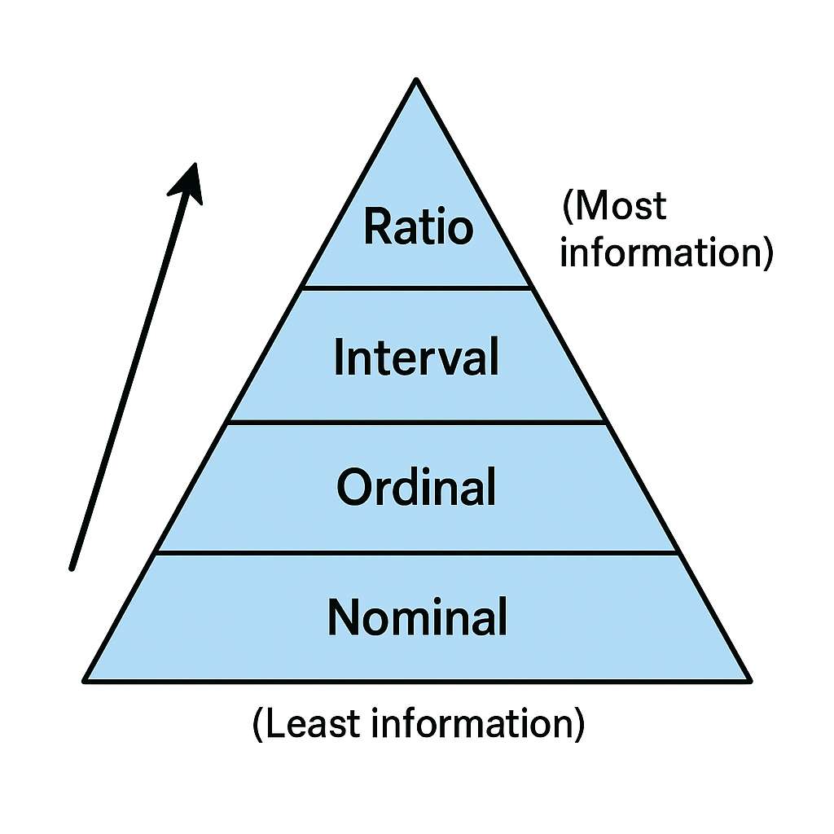

Image Credit: GPT

**Key principle**: You can always move DOWN the hierarchy (lose information) but never UP (can’t create information that wasn’t collected).

### Example: Income Data

Imagine surveying income:

**Ratio approach**: “What was your income last year? $_____”

- Can calculate exact averages, ratios, all statistics
- Can later group into brackets if needed

**Ordinal approach**: “Select your income bracket: Low / Medium / High”

- Can only find which bracket is most common
- Can NEVER recover exact income values
- Lost information forever!

## Practical Guidelines

### Choosing How to Measure

When designing data collection:

1. **Collect at the highest level possible** - you can always simplify later
2. **Consider your analysis needs** - what statistics will you want to calculate?
3. **Balance precision with feasibility** - will respondents know/share exact values?

### Common Pitfalls to Avoid

1. **Treating ordinal as interval**: Just because you code “Strongly Agree” as 5 doesn’t mean it’s 5 times more than “Strongly Disagree” (1)
2. **Over-aggregating**: Converting exact ages to “Young/Old” loses valuable information
3. **Wrong data type in R**: Zip codes stored as numeric (leading zeros disappear!)

```r
# Bad: Zip code as numeric loses leading zeros
zip_numeric <- 01234
zip_numeric  # Prints as 1234!
```

```
## [1] 1234
```

```r
# Good: Zip code as character preserves format
zip_character <- "01234"
zip_character  # Keeps the leading zero
```

```
## [1] "01234"
```

## Summary

Understanding data types and measurement levels is fundamental to data analysis:

- **R data types** determine how your computer stores and processes data
- **Measurement levels** determine what analyses are mathematically meaningful
- **Always collect data at the highest level possible** - you can simplify but can’t add detail
- **Match your analysis to your measurement level** to avoid nonsensical results

Remember: Just because R lets you calculate something doesn’t mean it’s meaningful. Understanding these concepts helps you avoid the trap of “garbage in, garbage out” in your analyses.

## Study Questions

### Data Types in R

1. What are the five main data types in R? Give an example of each from political science.
2. Why does R prevent you from calculating the mean of a character variable?
3. What function do you use to check a variable’s data type? What function converts a variable to numeric?
4. What happens when you try to convert the text “Democracy” to numeric? Why?

### Factors

5. What are the advantages of using factors instead of character variables for categorical data?
6. How are factors stored internally in R? How can you see this internal storage?
7. If you have a factor variable for U.S. regions with levels “Northeast”, “South”, “Midwest”, and “West”, what number would R internally use to store “Midwest”?

### Levels of Measurement

8. What are the four levels of measurement? List them from least to most information.
9. For each level of measurement, give an example NOT mentioned in the reading.
10. Why can temperature in Fahrenheit not be measured on a ratio scale?
11. What statistical measures are appropriate for ordinal but NOT nominal data?

### Converting Between Levels

12. Can you convert a nominal variable to a ratio variable? Why or why not?
13. If you collected exact ages but later grouped them into “Young/Middle-aged/Old”, what level of measurement did you convert FROM and TO?
14. Give an example where converting from a higher to lower measurement level would be scientifically justified.

### Discrete vs. Continuous

15. Is the number of bills passed by Congress discrete or continuous? Why?
16. Is voter turnout percentage discrete or continuous? Why?

### Practical Applications

17. You’re designing a survey question about income. What are the trade-offs between asking for exact income (ratio) versus income brackets (ordinal)?
18. A student codes survey responses “Strongly Disagree=1” through “Strongly Agree=5” and calculates the mean as 3.2. What’s wrong with reporting “the average response was 3.2”?
19. Why might you store zip codes as character variables rather than numeric, even though they’re “numbers”?
20. You have a dataset where religious affiliation is coded as: Christian=1, Jewish=2, Muslim=3, Other=4, None=5. A colleague suggests analyzing this as numeric to see if “religious affiliation increases” in your sample. What’s wrong with this approach?